# STAA 566 - Homework 3 - Mapping

Alexis Suhr

03 March 2022

### Summary for Assignment:

**Data Source**  
US Population Data 2015, from package ‘usmap’. Additional COVID statistics that did not end up being used, with sources linked below.

**Spatial Units Being Displayed**  
The population for each state in 2015.

**What you are trying to communicate**  
Originally, I wanted to communicate some statistics related to COVID-19 in the US. However, as I went through the mapping process, it seemed as though the data I had found (and took time to clean/modify) may be showing incorrect values. I wanted to scale the cases and deaths by population to give a more standardized view based on state size. Instead, I took the opportunity to work with multiple mapping features to get a better feel for mapping in R in the future.

**What decisions you made and why you made those to best communicate the data.**  
I decided to use the population data for 2015 instead of the COVID dataframe that I had put together. I realized that I wanted to take something of significance from this assignment to use in future mapping project, so I ended up applying a few different coloring schemes from the ‘viridis’ package to the same map.

### Libraries, Packages:

```r
######
# Install Packages
######

# This command can check for all libraries/packages that have been loaded or already exist, if needed.
# May use this in other projects, just going to comment out for now so I have it.
#(library()$results[,1])

# **ONLY RUN IF CODE BELOW IF NEEDED - TAKES A WHILE**
# Can copy and paste below into the console if needed
# to avoid including in the knitting


# install.packages(c('ggplot2',
# 'tidyverse',
# 'plotly',
# 'readr',
# 'rworldmap',
# 'sf',
# 'rgeos',
# 'poliscidata',
# 'tigris',
# 'usmap',
# 'viridis',
# 'gridExtra'))


######
# Read in libraries to be used
######

libs <- c('ggplot2',
          'tidyverse',
          'plotly',
          'readr',
          'rworldmap',
          'sf',
          'rgeos',
          'poliscidata',
          'tigris',
          'usmap',
          'viridis',
          'gridExtra')
for(l in libs){
  suppressPackageStartupMessages(library(l,
                                         quietly = TRUE,
                                         character.only = TRUE))
}

rm(l)
rm(libs)
```

### Reading in and Cleaning/Modifying Data:

```r
######
# Loading/Reformatting
#
# Need to aggregate to a monthly scale for Jan2020-Dec2021
# Need to re-format state NAMES to state CODES
######

COVID_Data <- na.omit(
  read.csv("/cloud/project/Datasets/COVID_Data_1Jan2020_to_3Mar2022.txt") %>%
    mutate(DateRecorded = date,
           Year = substr(date, 1, 4),
           Month = substr(date, 6, 7),
           YearMonth = substr(date, 1, 7),
           StateAbbreviation = as.factor(state.abb[match(state, state.name)]),
           NumCases = cases,
           NumDeaths = deaths) %>%
    select(StateAbbreviation,
           DateRecorded,
           Month,
           Year,
           YearMonth,
           NumCases,
           NumDeaths)
)

MaskMandate_Data <- na.omit(
  read.csv("/cloud/project/Datasets/MaskMandates2.txt") %>%
    mutate(StateAbbreviation = as.factor(StatePostal),
           Year = substr(DateEnacted, 1, 4),
           Month = substr(DateEnacted, 5, 6),
           YearMonth = paste0(substr(DateEnacted, 1, 4),
                              '-',
                              substr(DateEnacted, 5, 6)),
           DateRecorded = paste0(substr(DateEnacted, 1, 4),
                                 '-',
                                 substr(DateEnacted, 5, 6),
                                 '-',
                                 substr(DateEnacted, 7, 8)),
           FirstOfRecordedMonth = paste0(substr(DateEnacted, 1, 4),
                                         '-',
                                         substr(DateEnacted, 5, 6),
                                         '-01')
    ) %>%
    select(StateAbbreviation,
           FirstOfRecordedMonth,
           Month,
           Year,
           YearMonth,
           Mandate) %>%
    # removing "DC", "PR", "VI" to match other data frame states
    filter(StateAbbreviation %in% c("AK", "AL", "AR", "AZ", "CA", "CO", "CT", #"DC,
                                    "DE", "FL", "GA", "HI", "IA", "ID", "IL", "IN",
                                    "KS", "KY", "LA", "MA", "MD", "ME", "MI", "MN",
                                    "MO", "MS", "MT", "NC", "ND", "NE", "NH", "NJ",
                                    "NM", "NV", "NY", "OH", "OK", "OR", "PA", "RI",
                                    "SC", "SD", "TN", "TX", "UT", "VA", "VT", "WA",
                                    "WI", "WV", "WY")
    )

)




Population_Data <- na.omit(
  read.csv("/cloud/project/Datasets/US_PopulationByState.csv") %>%
    mutate(StateAbbreviation = state.abb[match(NAME, state.name)],
           Popn2020 = POPESTIMATE2020,
           Popn2021 = POPESTIMATE2021) %>%
    select(StateAbbreviation,
           Popn2020,
           Popn2021)
)



######
# Splitting the populations for 2020 and 2021 into two separate data frames ######
# to paste them as rows on top of each other ######
######

Popn2020 <- Population_Data %>%
  select(StateAbbreviation,
         Popn2020) %>%
  mutate(Year = '2020')

colnames(Popn2020) <- c("StateAbbreviation",
                        "Population",
                        "Year")

Popn2021 <- Population_Data %>%
  select(StateAbbreviation,
         Popn2021) %>%
  mutate(Year = '2021')

colnames(Popn2021) <- c("StateAbbreviation",
                        "Population",
                        "Year")

PopulationCombined <- rbind(Popn2020,
                            Popn2021)

rm(Popn2020)
rm(Popn2021)


testpop <- rbind(PopulationCombined, PopulationCombined, PopulationCombined,
                 PopulationCombined, PopulationCombined, PopulationCombined,
                 PopulationCombined, PopulationCombined, PopulationCombined,
                 PopulationCombined, PopulationCombined, PopulationCombined)

testpop$Month <- rep(seq(1, 12, 1), 100)
testpop$Month <- ifelse(testpop$Month < 10, paste0('0', testpop$Month), testpop$Month)

testpop$YearMonth <- paste0(testpop$Year,
                            '-',
                            testpop$Month)
PopulationFinal <- testpop


COVID_Cases_By_Month <- COVID_Data %>%
  group_by(StateAbbreviation, YearMonth) %>%
  summarise(TotalMonthlyCases = sum(NumCases),
            TotalMonthlyDeaths = sum(NumDeaths))
rm(testpop)
rm(PopulationCombined)
rm(Population_Data)


######
# Getting same dates for each dataset and printing final ones to be used
######

Mandates <- MaskMandate_Data %>%
  group_by(StateAbbreviation, YearMonth) %>%
  summarise(TotalMandatesByState = sum(Mandate))
MaskMandate_Data <- Mandates

COVID_Cases_By_Month <- COVID_Cases_By_Month %>%
  filter(YearMonth > "2020-01",
         YearMonth < "2021-10")

PopulationFinal <- PopulationFinal %>%
  filter(YearMonth > "2020-01",
         YearMonth < "2021-10")

# head(COVID_Cases_By_Month)
# head(MaskMandate_Data)
# head(PopulationFinal)

Final_Data <- inner_join(COVID_Cases_By_Month, PopulationFinal)
Final_Data <- inner_join(Final_Data, MaskMandate_Data)
Final_Data <- Final_Data %>%
  select(-c(Year,
            Month))

######
# Adding Variables for Analysis/Mapping:
#
# Cases scaled by population
# Deaths scaled by population
# Deaths scaled by cases
######


Final_Data <- Final_Data %>%
  mutate(CasesByPopulation = ifelse(TotalMonthlyCases > 0, round(TotalMonthlyCases/Population, 4), 0),
         DeathsByPopulation = ifelse(TotalMonthlyDeaths > 0, round(TotalMonthlyDeaths/Population, 4), 0),
         DeathsByCases = ifelse(TotalMonthlyCases > 0, round(TotalMonthlyDeaths/TotalMonthlyCases, 4), 0)
  )
Final_Data <- na.omit(Final_Data)
head(Final_Data)
```

```
## # A tibble: 6 × 9
## # Groups:   StateAbbreviation [2]
##   StateAbbreviation YearMonth TotalMonthlyCases TotalMonthlyDeaths Population
##   <chr>             <chr>                 <int>              <int>      <int>
## 1 AL                2020-05              372033              14438    5024803
## 2 AL                2020-05              372033              14438    5024803
## 3 AL                2020-05              372033              14438    5024803
## 4 AL                2020-05              372033              14438    5024803
## 5 AR                2020-04               53571               1007    3012232
## 6 AR                2020-04               53571               1007    3012232
## # … with 4 more variables: TotalMandatesByState <int>, CasesByPopulation <dbl>,
## #   DeathsByPopulation <dbl>, DeathsByCases <dbl>
```

### Summarizing and Plotting the Data

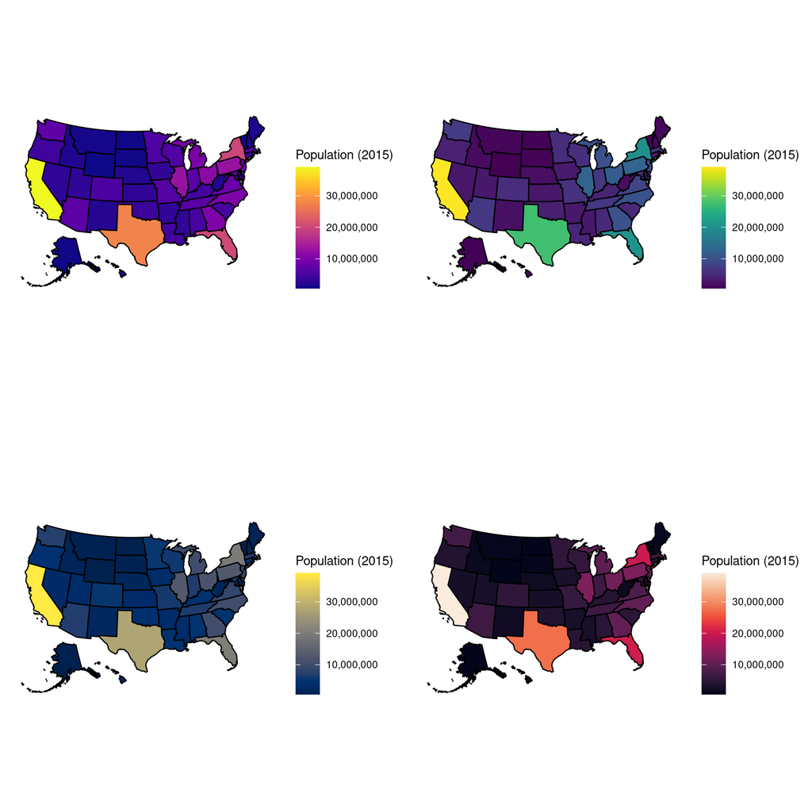

```r
######  Mapping Attempt 1 - using 'usmap' library/data ######

grid.arrange(

plot_usmap(data = statepop,
           values = "pop_2015",
           color = "black") +
  scale_fill_viridis(option = "C",
                     name = "Population (2015)",
                        label = scales::comma) +
  theme(legend.position = "right"),

plot_usmap(data = statepop,
           values = "pop_2015",
           color = "black") +
  scale_fill_viridis(option = "D",
                     name = "Population (2015)",
                        label = scales::comma) +
  theme(legend.position = "right"),

plot_usmap(data = statepop,
           values = "pop_2015",
           color = "black") +
  scale_fill_viridis(option = "E",
                     name = "Population (2015)",
                        label = scales::comma) +
  theme(legend.position = "right"),
plot_usmap(data = statepop,
           values = "pop_2015",
           color = "black") +
  scale_fill_viridis(option = "F",
                     name = "Population (2015)",
                        label = scales::comma) +
  theme(legend.position = "right"),
nrow = 2)
```

```r
######  Mapping Attempt 2 - using *my* COVID dataframe ######
#
# Final_Data$state = Final_Data$StateAbbreviation
# Mandates$state <- Mandates$StateAbbreviation
#
#
# plot_usmap(data = Mandates %>%
#              filter(YearMonth == "2021-06"),
#            values = "TotalMandatesByState") +
#   labs(title = "Mask Mandates by State in the US",
#        subtitle = "Aug 2021")+
#   theme(legend.position = "right")+
#   scale_fill_viridis(name = "Mandates per State  - Aug 2021")
#
#
# plot_usmap(data = Final_Data %>%
#              filter(YearMonth == "2021-04"),
#            values = "CasesByPopulation") +
#   labs(title = "Total COVID Cases by State in the US",
#        subtitle = "February 2021")+
#   theme(legend.position = "right")+
#   scale_fill_viridis(option = "A",
#                      name = "Total COVID Cases per Population - Feb 2021")
#
# plot_usmap(data = Final_Data %>%
#              filter(YearMonth == "2021-01"),
#            values = "DeathsByPopulation") +
#   labs(title = "Total COVID Cases by State in the US",
#        subtitle = "March 2021")+
#   theme(legend.position = "right")+
#   scale_fill_viridis(option = "D",
#                      name = "Total COVID Deaths per Population - March 2021",
#                      label = scales::comma)
#
#
```

#### Sources for Data Used

1. COVID Cases and Deaths by State (2020-2021): https://www.kaggle.com/sudalairajkumar/covid19-in-usa/version/102?select=us_states_covid19_daily.csv
2. COVID Mask Mandates by State (2020-2021): https://github.com/COVID19StatePolicy/SocialDistancing/blob/master/data/USstatesCov19distancingpolicy.csv
3. Population by State (2020-2021):  
   https://www2.census.gov/programs-surveys/popest/datasets/